# Project on Fixer.io to find out the Currency Exchnage Pattern for EURO, INR and GBP

```python
import os
import urllib.request
import csv
import pandas as pd
import requests
import datetime
from datetime import timedelta
import json
import pandas as pd
import numpy as np
import matplotlib.pyplot as plt
%matplotlib inline
```

# Task 1: Identify one or more suitable web APIs

## API chosen:

A single API was chosen for this assignment that was provided by https://fixer.io/

It gives the real time exchange rate for available currencies It has 1000 api calls and the data is hourly updated

The API key I recieved is  
e19104f18048dfe3e16b24c9a1ec9015

```python
api_key = "e19104f18048dfe3e16b24c9a1ec9015"
```

# Task 2: Collect data your chosen API(s)

Collecting the Raw data from api which is in jason format and we need to import it to python format

Base URL is http://data.fixer.io/api/latest?access_key=e19104f18048dfe3e16b24c9a1ec9015

```python
Base_url = "http://data.fixer.io/api/latest?access_key=e19104f18048dfe3e16b24c9a1ec9015"
response = urllib.request.urlopen(Base_url)
raw_json = response.read().decode()
print(raw_json)
```

```
{"success":true,"timestamp":1522162449,"base":"EUR","date":"2018-03-27","rates":{"AED":4.552796,"AFN":85.667922,"ALL":131.16739,"AMD":594.803172,"ANG":2.206631,"AOA":263.296841,"ARS":25.003627,"AUD":1.608848,"AWG":2.206786,"AZN":2.106986,"BAM":1.958085,"BBD":2.479535,"BDT":102.764315,"BGN":1.959206,…
```

```python
import json
data = json.loads(raw_json)
print(data)
```

```
{'success': True, 'timestamp': 1522162449, 'base': 'EUR', 'date': '2018-03-27', 'rates': {'AED': 4.552796, 'AFN': 85.667922, 'ALL': 131.16739, 'AMD': 594.803172, 'ANG': 2.206631, 'AOA': 263.296841, 'ARS': 25.003627, 'AUD': 1.608848, 'AWG': 2.206786, 'AZN': 2.106986, 'BAM': 1.958085, 'BBD': 2.479535,…
```

### Writing function for collecting historic data

Since the data we are getting the current data for that date, so to collect the data from history we need to write the function for it. The import datetime and import timedelta has the inbuilt function to get the current date and time and a historic one as well. So here writing the function to get the current date or todays date and starting year and first day of that year,

Though the data is available with key and also without key that is no authentication is needed. so here im passing the direct link to the function

```python
# getting today's date
today = datetime.datetime.now()

# providing the start_date for collecting the data from that date onwards
st_year = 2010
day = "%02d" % 1      #collecting the each month's 1st days rate

# Get the present year and month from timedelta inbuilt function
curnt_year = today.year
curnt_month = today.month

# define base currency
base_currency = "INR"
```

```python
# Defining the load function to load the data
def load_data():

    # making the variables global so that all the loops can access it
    global st_year, day,curnt_month, curnt_year, base_currency

    # initializing the json object
    json_data = {}

    while st_year <= curnt_year:        #this will run till current year
        if st_year == curnt_year:       # condition for checking the current month
            month_end = curnt_month
        else:
            month_end = 12

        for month in range(1, month_end+1):

            today = str(st_year) + "-" + str("%02d" % month) + "-" + str(day)  # collecting the every month's 1st date's data

            url = "https://api.fixer.io/" + today + "?base=" + base_currency     # collecting the todays data with base
                                                                                   #currency as USD
            #print(today, url)
            r = requests.get(url)
            data = r.json()               #reading the data in json format

            json_data[today] = data["rates"]        #getting the todays rate for all currency
        st_year += 1                                # incrementing the year

    return json_data                          #return the data in json format json_data object
```

# Task 3: Parse the collected data, and store it in an appropriate file format

## Parsing the Data to from json format to python

Once we have the data in json object then we can parse it into python this can be done by below code

```python
# loading the data into json
json_data = load_data()
```

```python
print(json_data["2018-02-01"])    #checking whether its printing the data for particular day
```

```
{'AUD': 0.019516, 'BGN': 0.024519, 'BRL': 0.049505, 'CAD': 0.019241, 'CHF': 0.014546, 'CNY': 0.098351, 'CZK': 0.31676, 'DKK': 0.093308, 'EUR': 0.012537, 'GBP': 0.010972, 'HKD': 0.12214, 'HRK': 0.093179, 'HUF': 3.8871, 'IDR': 209.58, 'ILS': 0.05355, 'ISK': 1.5672, 'JPY': 1.7128, 'KRW': 16.73, 'MXN': …
```

```python
json_data_py = json.dumps(json_data)   #dumping the data from json to python
json_data_py
```

```
'{"2010-01-01": {"AUD": 0.023878, "BGN": 0.029174, "BRL": 0.03746, "CAD": 0.022566, "CHF": 0.02213, "CNY": 0.1467, "CZK": 0.39488, "DKK": 0.11101, "EEK": 0.2334, "EUR": 0.014916, "GBP": 0.013247, "HKD": 0.16663, "HRK": 0.10889, "HUF": 4.0337, "IDR": 203.25, "JPY": 1.9863, "KRW": 24.866, "LTL": 0.051…
```

# Task 4: Load and represent the data using an appropriate data structure. Apply any pre-processing steps to clean/filter/combine the data

### Here importing the json data to pandas for cleaning and pre-processing

Once we have the data in json fromat we can convert it into a dataframe of pandas for esy pre-processing and cleaning and extracting the data from the same.

Here the data contains some of the null values as "Not a Number" so we have to take care of these values since i'm considering the currencies with values and the data contains five currencies which are incomplete they are "EEK", "ILS", "ISK", "LTL", "LVL".

As pre-processing i'm removing these values from the dataframe of pandas so that we can have clear data with no null values. once you done with cleaning and pre-processing and transposing them to appropriate format. write them to a csv file and store to a current working directory.

```python
import pandas as pd
df = pd.read_json(json_data_py)
df
```

|  | 2010-01-01 00:00:00 | 2010-02-01 00:00:00 | 2010-03-01 00:00:00 | 2010-04-01 00:00:00 | 2010-05-01 00:00:00 | 2010-06-01 00:00:00 | 2010-07-01 00:00:00 | 2010-08-01 00:00:00 | 2010-09-01 00:00:00 | 2010-10-01 00:00:00 | ... | 2017-06-01 00:00:00 | 2017-07-01 00:00:00 | 2017-08-01 00:00:00 | 2017-09-01 00:00:00 | 2017-10-01 00:00:00 | 2017-11-01 00:00:00 | 2017-12-01 00:00:00 | 2018-01-01 00:00:00 | 2018-02-01 00:00:00 | 2018-03-01 00:00:00 |
| --- | --- | --- | --- | --- | --- | --- | --- | --- | --- | --- | --- | --- | --- | --- | --- | --- | --- | --- | --- | --- | --- |
| AUD | 0.023878 | 0.024407 | 0.024202 | 0.024393 | 0.024197 | 0.025464 | 0.025665 | 0.023931 | 0.023599 | 0.023107 | ... | 0.020992 | 0.020139 | 0.019564 | 0.019680 | 0.019560 | 0.020178 | 0.020472 | 0.020032 | 0.019516 | 0.019850 |
| BGN | 0.029174 | 0.030312 | 0.031337 | 0.032487 | 0.033113 | 0.034123 | 0.034025 | 0.032354 | 0.032639 | 0.032020 | ... | 0.027042 | 0.026521 | 0.025831 | 0.025624 | 0.025377 | 0.026073 | 0.025514 | 0.025531 | 0.024519 | 0.024656 |
| BRL | 0.037460 | 0.040482 | 0.039209 | 0.039788 | 0.038871 | 0.038840 | 0.038859 | 0.037922 | 0.037330 | 0.037714 | ... | 0.049963 | 0.050987 | 0.048710 | 0.049029 | 0.048833 | 0.050858 | 0.050648 | 0.051861 | 0.049505 | 0.050098 |
| CAD | 0.022566 | 0.023043 | 0.022858 | 0.022627 | 0.022651 | 0.022273 | 0.022831 | 0.022256 | 0.022629 | 0.023060 | ... | 0.020954 | 0.020049 | 0.019464 | 0.019429 | 0.019057 | 0.019978 | 0.019961 | 0.019632 | 0.019241 | 0.019734 |
| CHF | 0.022130 | 0.022822 | 0.023464 | 0.023552 | 0.024280 | 0.024745 | 0.022925 | 0.022400 | 0.021639 | 0.021976 | ... | 0.015048 | 0.014822 | 0.015075 | 0.014989 | 0.014866 | 0.015517 | 0.015251 | 0.015276 | 0.014546 | 0.014521 |
| CNY | 0.146700 | 0.147220 | 0.147930 | 0.152710 | 0.153860 | 0.144850 | 0.145430 | 0.146010 | 0.145500 | 0.150360 | ... | 0.105620 | 0.104940 | 0.104830 | 0.102430 | 0.101900 | 0.102340 | 0.102470 | 0.101880 | 0.098351 | 0.097436 |
| CZK | 0.394880 | 0.403970 | 0.415520 | 0.421660 | 0.432180 | 0.447130 | 0.448310 | 0.409880 | 0.412780 | 0.399800 | ... | 0.364980 | 0.355240 | 0.345140 | 0.341640 | 0.337110 | 0.340700 | 0.332970 | 0.333330 | 0.316760 | 0.320630 |
| DKK | 0.111010 | 0.115390 | 0.119250 | 0.123660 | 0.126010 | 0.129790 | 0.129580 | 0.123260 | 0.124240 | 0.122010 | ... | 0.102860 | 0.100840 | 0.098224 | 0.097445 | 0.096567 | 0.099203 | 0.097084 | 0.097184 | 0.093308 | 0.093881 |
| EEK | 0.233400 | 0.242510 | 0.250710 | 0.259910 | 0.264910 | 0.272990 | 0.272210 | 0.258840 | 0.261120 | 0.256170 | ... | NaN | NaN | NaN | NaN | NaN | NaN | NaN | NaN | NaN | NaN |
| EUR | 0.014916 | 0.015499 | 0.016023 | 0.016611 | 0.016931 | 0.017447 | 0.017397 | 0.016543 | 0.016688 | 0.016372 | ... | 0.013827 | 0.013560 | 0.013208 | 0.013101 | 0.012975 | 0.013331 | 0.013045 | 0.013054 | 0.012537 | 0.012607 |
| GBP | 0.013247 | 0.013559 | 0.014528 | 0.014698 | 0.014735 | 0.014563 | 0.014303 | 0.013811 | 0.013869 | 0.014204 | ... | 0.012061 | 0.011924 | 0.011813 | 0.012063 | 0.011441 | 0.011649 | 0.011495 | 0.011582 | 0.010972 | 0.011159 |
| HKD | 0.166630 | 0.167490 | 0.168260 | 0.173750 | 0.175010 | 0.165260 | 0.167110 | 0.167380 | 0.166120 | 0.174380 | ... | 0.120870 | 0.120780 | 0.121880 | 0.122200 | 0.119650 | 0.120770 | 0.121130 | 0.122340 | 0.122140 | 0.120090 |
| HRK | 0.108890 | 0.113380 | 0.116270 | 0.120660 | 0.122800 | 0.126650 | 0.125130 | 0.119700 | 0.121450 | 0.119540 | ... | 0.102500 | 0.100490 | 0.097855 | 0.097232 | 0.097251 | 0.100250 | 0.098562 | 0.097120 | 0.093179 | 0.093893 |
| HUF | 4.033700 | 4.205500 | 4.317300 | 4.398200 | 4.517400 | 4.826100 | 5.000700 | 4.724900 | 4.777800 | 4.483400 | ... | 4.252400 | 4.189800 | 4.009800 | 3.997100 | 4.031100 | 4.155900 | 4.093700 | 4.051000 | 3.887100 | 3.955700 |
| IDR | 203.250000 | 202.640000 | 200.610000 | 203.480000 | 203.120000 | 196.280000 | 194.170000 | 192.670000 | 192.110000 | 200.260000 | ... | 206.460000 | 206.240000 | 207.860000 | 207.980000 | 206.170000 | 210.280000 | 209.810000 | 211.980000 | 209.580000 | 211.790000 |
| ILS | NaN | NaN | NaN | NaN | NaN | NaN | NaN | NaN | NaN | NaN | ... | 0.055085 | 0.054090 | 0.055658 | 0.055810 | 0.053966 | 0.054451 | 0.054135 | 0.054350 | 0.053550 | 0.053448 |
| ISK | NaN | NaN | NaN | NaN | NaN | NaN | NaN | NaN | NaN | NaN | ... | NaN | NaN | NaN | NaN | NaN | NaN | NaN | NaN | 1.567200 | 1.559400 |
| JPY | 1.986300 | 1.946600 | 1.933500 | 2.097600 | 2.130000 | 1.930500 | 1.881300 | 1.863000 | 1.794600 | 1.870600 | ... | 1.721800 | 1.732300 | 1.724000 | 1.720100 | 1.723400 | 1.767700 | 1.744200 | 1.762400 | 1.712800 | 1.638600 |
| KRW | 24.866000 | 25.218000 | 25.031000 | 25.198000 | 24.981000 | 25.792000 | 26.351000 | 25.525000 | 25.311000 | 25.312000 | ... | 17.399000 | 17.691000 | 17.507000 | 17.496000 | 17.540000 | 17.217000 | 16.796000 | 16.704000 | 16.730000 | 16.685000 |
| LTL | 0.051504 | 0.053514 | 0.055324 | 0.057354 | 0.058458 | 0.060240 | 0.060067 | 0.057118 | 0.057621 | 0.056528 | ... | NaN | NaN | NaN | NaN | NaN | NaN | NaN | NaN | NaN | NaN |
| LVL | 0.010580 | 0.010984 | 0.011363 | 0.011775 | 0.011977 | 0.012375 | 0.012340 | 0.011725 | 0.011834 | 0.011611 | ... | NaN | NaN | NaN | NaN | NaN | NaN | NaN | NaN | NaN | NaN |
| MXN | 0.282250 | 0.281140 | 0.276360 | 0.276070 | 0.275050 | 0.275470 | 0.277630 | 0.274180 | 0.280580 | 0.281510 | ... | 0.289250 | 0.279130 | 0.277390 | 0.278550 | 0.278460 | 0.296960 | 0.289530 | 0.308870 | 0.289990 | 0.290400 |
| MYR | 0.073577 | 0.073632 | 0.073344 | 0.072896 | 0.071789 | 0.070141 | 0.069359 | 0.068556 | 0.066831 | 0.069337 | ... | 0.066516 | 0.066427 | 0.066857 | 0.066691 | 0.064652 | 0.065503 | 0.063427 | 0.063358 | 0.060978 | 0.060277 |
| NOK | 0.123810 | 0.127030 | 0.129100 | 0.133170 | 0.132810 | 0.138560 | 0.139960 | 0.131360 | 0.132550 | 0.131630 | ... | 0.131210 | 0.129790 | 0.123280 | 0.121260 | 0.122130 | 0.126120 | 0.128830 | 0.128450 | 0.119980 | 0.121780 |
| NZD | 0.029539 | 0.030647 | 0.031152 | 0.031775 | 0.030905 | 0.031502 | 0.031422 | 0.029798 | 0.030225 | 0.030370 | ... | 0.021943 | 0.021092 | 0.020885 | 0.021798 | 0.021220 | 0.022484 | 0.022633 | 0.021996 | 0.021242 | 0.021262 |
| PHP | 0.992050 | 1.005400 | 0.999490 | 1.010600 | 1.002100 | 0.989390 | 0.996850 | 0.981690 | 0.963570 | 0.983380 | ... | 0.771200 | 0.780740 | 0.785960 | 0.797870 | 0.779170 | 0.799950 | 0.781070 | 0.780550 | 0.806480 | 0.797220 |
| PLN | 0.061225 | 0.062064 | 0.063130 | 0.063882 | 0.066305 | 0.071776 | 0.072666 | 0.066311 | 0.066579 | 0.064455 | ... | 0.057837 | 0.057305 | 0.056215 | 0.055558 | 0.055849 | 0.056441 | 0.054959 | 0.054526 | 0.052081 | 0.052762 |
| RON | 0.063191 | 0.063332 | 0.065870 | 0.068239 | 0.069923 | 0.073046 | 0.075575 | 0.070319 | 0.071171 | 0.069833 | ... | 0.063167 | 0.061731 | 0.060221 | 0.060218 | 0.059678 | 0.061367 | 0.060407 | 0.060811 | 0.058356 | 0.058712 |
| RUB | 0.643710 | 0.654830 | 0.649680 | 0.657750 | 0.657560 | 0.663490 | 0.671180 | 0.652060 | 0.656790 | 0.684340 | ... | 0.878450 | 0.915940 | 0.940050 | 0.901660 | 0.885600 | 0.899980 | 0.909230 | 0.905830 | 0.879100 | 0.872110 |
| SEK | 0.152920 | 0.157190 | 0.156460 | 0.161600 | 0.162900 | 0.167770 | 0.167040 | 0.156050 | 0.156020 | 0.150920 | ... | 0.135170 | 0.130720 | 0.126220 | 0.124170 | 0.125200 | 0.130020 | 0.129790 | 0.128500 | 0.122900 | 0.127550 |
| SGD | 0.030122 | 0.030455 | 0.030485 | 0.031271 | 0.030842 | 0.029996 | 0.029966 | 0.029335 | 0.028832 | 0.029495 | ... | 0.021466 | 0.021303 | 0.021188 | 0.021153 | 0.020801 | 0.021074 | 0.020891 | 0.020917 | 0.020500 | 0.020360 |
| THB | 0.715780 | 0.715680 | 0.712600 | 0.724380 | 0.729380 | 0.691020 | 0.695300 | 0.695580 | 0.665900 | 0.678820 | ... | 0.529740 | 0.525390 | 0.519350 | 0.518010 | 0.510430 | 0.513310 | 0.505920 | 0.510680 | 0.489820 | 0.484390 |
| TRY | 0.032141 | 0.032152 | 0.033454 | 0.034020 | 0.033450 | 0.033651 | 0.034014 | 0.032594 | 0.032517 | 0.032508 | ... | 0.054913 | 0.054423 | 0.054946 | 0.053691 | 0.054513 | 0.059182 | 0.060946 | 0.059348 | 0.058517 | 0.058538 |
| USD | 0.021489 | 0.021563 | 0.021671 | 0.022371 | 0.022543 | 0.021207 | 0.021447 | 0.021552 | 0.021361 | 0.022472 | ... | 0.015512 | 0.015475 | 0.015601 | 0.015617 | 0.015319 | 0.015480 | 0.015505 | 0.015655 | 0.015619 | 0.015343 |
| ZAR | 0.159100 | 0.163260 | 0.166490 | 0.162820 | 0.165290 | 0.163880 | 0.166740 | 0.158170 | 0.157190 | 0.155730 | ... | 0.202440 | 0.202320 | 0.207250 | 0.202000 | 0.206880 | 0.218510 | 0.212520 | 0.193260 | 0.185840 | 0.183050 |

35 rows × 99 columns

# Since the data contains the Null values

#### The data contains the null values or for few of the currencies it gives "Not A Number", so we have to remove that from the file and data frame and make it more clear data.

```python
df.drop(['EEK', 'ILS', 'ISK', 'LTL', 'LVL'],inplace=True)  # inplace make sure the changes also made to original dataframe
df
```

|  | 2010-01-01 00:00:00 | 2010-02-01 00:00:00 | 2010-03-01 00:00:00 | 2010-04-01 00:00:00 | 2010-05-01 00:00:00 | 2010-06-01 00:00:00 | 2010-07-01 00:00:00 | 2010-08-01 00:00:00 | 2010-09-01 00:00:00 | 2010-10-01 00:00:00 | ... | 2017-06-01 00:00:00 | 2017-07-01 00:00:00 | 2017-08-01 00:00:00 | 2017-09-01 00:00:00 | 2017-10-01 00:00:00 | 2017-11-01 00:00:00 | 2017-12-01 00:00:00 | 2018-01-01 00:00:00 | 2018-02-01 00:00:00 | 2018-03-01 00:00:00 |
| --- | --- | --- | --- | --- | --- | --- | --- | --- | --- | --- | --- | --- | --- | --- | --- | --- | --- | --- | --- | --- | --- |
| AUD | 0.023878 | 0.024407 | 0.024202 | 0.024393 | 0.024197 | 0.025464 | 0.025665 | 0.023931 | 0.023599 | 0.023107 | ... | 0.020992 | 0.020139 | 0.019564 | 0.019680 | 0.019560 | 0.020178 | 0.020472 | 0.020032 | 0.019516 | 0.019850 |
| BGN | 0.029174 | 0.030312 | 0.031337 | 0.032487 | 0.033113 | 0.034123 | 0.034025 | 0.032354 | 0.032639 | 0.032020 | ... | 0.027042 | 0.026521 | 0.025831 | 0.025624 | 0.025377 | 0.026073 | 0.025514 | 0.025531 | 0.024519 | 0.024656 |
| BRL | 0.037460 | 0.040482 | 0.039209 | 0.039788 | 0.038871 | 0.038840 | 0.038859 | 0.037922 | 0.037330 | 0.037714 | ... | 0.049963 | 0.050987 | 0.048710 | 0.049029 | 0.048833 | 0.050858 | 0.050648 | 0.051861 | 0.049505 | 0.050098 |
| CAD | 0.022566 | 0.023043 | 0.022858 | 0.022627 | 0.022651 | 0.022273 | 0.022831 | 0.022256 | 0.022629 | 0.023060 | ... | 0.020954 | 0.020049 | 0.019464 | 0.019429 | 0.019057 | 0.019978 | 0.019961 | 0.019632 | 0.019241 | 0.019734 |
| CHF | 0.022130 | 0.022822 | 0.023464 | 0.023552 | 0.024280 | 0.024745 | 0.022925 | 0.022400 | 0.021639 | 0.021976 | ... | 0.015048 | 0.014822 | 0.015075 | 0.014989 | 0.014866 | 0.015517 | 0.015251 | 0.015276 | 0.014546 | 0.014521 |
| CNY | 0.146700 | 0.147220 | 0.147930 | 0.152710 | 0.153860 | 0.144850 | 0.145430 | 0.146010 | 0.145500 | 0.150360 | ... | 0.105620 | 0.104940 | 0.104830 | 0.102430 | 0.101900 | 0.102340 | 0.102470 | 0.101880 | 0.098351 | 0.097436 |
| CZK | 0.394880 | 0.403970 | 0.415520 | 0.421660 | 0.432180 | 0.447130 | 0.448310 | 0.409880 | 0.412780 | 0.399800 | ... | 0.364980 | 0.355240 | 0.345140 | 0.341640 | 0.337110 | 0.340700 | 0.332970 | 0.333330 | 0.316760 | 0.320630 |
| DKK | 0.111010 | 0.115390 | 0.119250 | 0.123660 | 0.126010 | 0.129790 | 0.129580 | 0.123260 | 0.124240 | 0.122010 | ... | 0.102860 | 0.100840 | 0.098224 | 0.097445 | 0.096567 | 0.099203 | 0.097084 | 0.097184 | 0.093308 | 0.093881 |
| EUR | 0.014916 | 0.015499 | 0.016023 | 0.016611 | 0.016931 | 0.017447 | 0.017397 | 0.016543 | 0.016688 | 0.016372 | ... | 0.013827 | 0.013560 | 0.013208 | 0.013101 | 0.012975 | 0.013331 | 0.013045 | 0.013054 | 0.012537 | 0.012607 |
| GBP | 0.013247 | 0.013559 | 0.014528 | 0.014698 | 0.014735 | 0.014563 | 0.014303 | 0.013811 | 0.013869 | 0.014204 | ... | 0.012061 | 0.011924 | 0.011813 | 0.012063 | 0.011441 | 0.011649 | 0.011495 | 0.011582 | 0.010972 | 0.011159 |
| HKD | 0.166630 | 0.167490 | 0.168260 | 0.173750 | 0.175010 | 0.165260 | 0.167110 | 0.167380 | 0.166120 | 0.174380 | ... | 0.120870 | 0.120780 | 0.121880 | 0.122200 | 0.119650 | 0.120770 | 0.121130 | 0.122340 | 0.122140 | 0.120090 |
| HRK | 0.108890 | 0.113380 | 0.116270 | 0.120660 | 0.122800 | 0.126650 | 0.125130 | 0.119700 | 0.121450 | 0.119540 | ... | 0.102500 | 0.100490 | 0.097855 | 0.097232 | 0.097251 | 0.100250 | 0.098562 | 0.097120 | 0.093179 | 0.093893 |
| HUF | 4.033700 | 4.205500 | 4.317300 | 4.398200 | 4.517400 | 4.826100 | 5.000700 | 4.724900 | 4.777800 | 4.483400 | ... | 4.252400 | 4.189800 | 4.009800 | 3.997100 | 4.031100 | 4.155900 | 4.093700 | 4.051000 | 3.887100 | 3.955700 |
| IDR | 203.250000 | 202.640000 | 200.610000 | 203.480000 | 203.120000 | 196.280000 | 194.170000 | 192.670000 | 192.110000 | 200.260000 | ... | 206.460000 | 206.240000 | 207.860000 | 207.980000 | 206.170000 | 210.280000 | 209.810000 | 211.980000 | 209.580000 | 211.790000 |
| JPY | 1.986300 | 1.946600 | 1.933500 | 2.097600 | 2.130000 | 1.930500 | 1.881300 | 1.863000 | 1.794600 | 1.870600 | ... | 1.721800 | 1.732300 | 1.724000 | 1.720100 | 1.723400 | 1.767700 | 1.744200 | 1.762400 | 1.712800 | 1.638600 |
| KRW | 24.866000 | 25.218000 | 25.031000 | 25.198000 | 24.981000 | 25.792000 | 26.351000 | 25.525000 | 25.311000 | 25.312000 | ... | 17.399000 | 17.691000 | 17.507000 | 17.496000 | 17.540000 | 17.217000 | 16.796000 | 16.704000 | 16.730000 | 16.685000 |
| MXN | 0.282250 | 0.281140 | 0.276360 | 0.276070 | 0.275050 | 0.275470 | 0.277630 | 0.274180 | 0.280580 | 0.281510 | ... | 0.289250 | 0.279130 | 0.277390 | 0.278550 | 0.278460 | 0.296960 | 0.289530 | 0.308870 | 0.289990 | 0.290400 |
| MYR | 0.073577 | 0.073632 | 0.073344 | 0.072896 | 0.071789 | 0.070141 | 0.069359 | 0.068556 | 0.066831 | 0.069337 | ... | 0.066516 | 0.066427 | 0.066857 | 0.066691 | 0.064652 | 0.065503 | 0.063427 | 0.063358 | 0.060978 | 0.060277 |
| NOK | 0.123810 | 0.127030 | 0.129100 | 0.133170 | 0.132810 | 0.138560 | 0.139960 | 0.131360 | 0.132550 | 0.131630 | ... | 0.131210 | 0.129790 | 0.123280 | 0.121260 | 0.122130 | 0.126120 | 0.128830 | 0.128450 | 0.119980 | 0.121780 |
| NZD | 0.029539 | 0.030647 | 0.031152 | 0.031775 | 0.030905 | 0.031502 | 0.031422 | 0.029798 | 0.030225 | 0.030370 | ... | 0.021943 | 0.021092 | 0.020885 | 0.021798 | 0.021220 | 0.022484 | 0.022633 | 0.021996 | 0.021242 | 0.021262 |
| PHP | 0.992050 | 1.005400 | 0.999490 | 1.010600 | 1.002100 | 0.989390 | 0.996850 | 0.981690 | 0.963570 | 0.983380 | ... | 0.771200 | 0.780740 | 0.785960 | 0.797870 | 0.779170 | 0.799950 | 0.781070 | 0.780550 | 0.806480 | 0.797220 |
| PLN | 0.061225 | 0.062064 | 0.063130 | 0.063882 | 0.066305 | 0.071776 | 0.072666 | 0.066311 | 0.066579 | 0.064455 | ... | 0.057837 | 0.057305 | 0.056215 | 0.055558 | 0.055849 | 0.056441 | 0.054959 | 0.054526 | 0.052081 | 0.052762 |
| RON | 0.063191 | 0.063332 | 0.065870 | 0.068239 | 0.069923 | 0.073046 | 0.075575 | 0.070319 | 0.071171 | 0.069833 | ... | 0.063167 | 0.061731 | 0.060221 | 0.060218 | 0.059678 | 0.061367 | 0.060407 | 0.060811 | 0.058356 | 0.058712 |
| RUB | 0.643710 | 0.654830 | 0.649680 | 0.657750 | 0.657560 | 0.663490 | 0.671180 | 0.652060 | 0.656790 | 0.684340 | ... | 0.878450 | 0.915940 | 0.940050 | 0.901660 | 0.885600 | 0.899980 | 0.909230 | 0.905830 | 0.879100 | 0.872110 |
| SEK | 0.152920 | 0.157190 | 0.156460 | 0.161600 | 0.162900 | 0.167770 | 0.167040 | 0.156050 | 0.156020 | 0.150920 | ... | 0.135170 | 0.130720 | 0.126220 | 0.124170 | 0.125200 | 0.130020 | 0.129790 | 0.128500 | 0.122900 | 0.127550 |
| SGD | 0.030122 | 0.030455 | 0.030485 | 0.031271 | 0.030842 | 0.029996 | 0.029966 | 0.029335 | 0.028832 | 0.029495 | ... | 0.021466 | 0.021303 | 0.021188 | 0.021153 | 0.020801 | 0.021074 | 0.020891 | 0.020917 | 0.020500 | 0.020360 |
| THB | 0.715780 | 0.715680 | 0.712600 | 0.724380 | 0.729380 | 0.691020 | 0.695300 | 0.695580 | 0.665900 | 0.678820 | ... | 0.529740 | 0.525390 | 0.519350 | 0.518010 | 0.510430 | 0.513310 | 0.505920 | 0.510680 | 0.489820 | 0.484390 |
| TRY | 0.032141 | 0.032152 | 0.033454 | 0.034020 | 0.033450 | 0.033651 | 0.034014 | 0.032594 | 0.032517 | 0.032508 | ... | 0.054913 | 0.054423 | 0.054946 | 0.053691 | 0.054513 | 0.059182 | 0.060946 | 0.059348 | 0.058517 | 0.058538 |
| USD | 0.021489 | 0.021563 | 0.021671 | 0.022371 | 0.022543 | 0.021207 | 0.021447 | 0.021552 | 0.021361 | 0.022472 | ... | 0.015512 | 0.015475 | 0.015601 | 0.015617 | 0.015319 | 0.015480 | 0.015505 | 0.015655 | 0.015619 | 0.015343 |
| ZAR | 0.159100 | 0.163260 | 0.166490 | 0.162820 | 0.165290 | 0.163880 | 0.166740 | 0.158170 | 0.157190 | 0.155730 | ... | 0.202440 | 0.202320 | 0.207250 | 0.202000 | 0.206880 | 0.218510 | 0.212520 | 0.193260 | 0.185840 | 0.183050 |

30 rows × 99 columns

#### since the format of the dataframe is not appropriate to plot the graphs

#### or any figures so transposing them to have the perfect variables and labels

#### with their values inside them

```python
# transposing the dataframe
df1 = df.T
df1
```

|  | AUD | BGN | BRL | CAD | CHF | CNY | CZK | DKK | EUR | GBP | ... | PHP | PLN | RON | RUB | SEK | SGD | THB | TRY | USD | ZAR |
| --- | --- | --- | --- | --- | --- | --- | --- | --- | --- | --- | --- | --- | --- | --- | --- | --- | --- | --- | --- | --- | --- |
| 2010-01-01 | 0.023878 | 0.029174 | 0.037460 | 0.022566 | 0.022130 | 0.146700 | 0.39488 | 0.111010 | 0.014916 | 0.013247 | ... | 0.99205 | 0.061225 | 0.063191 | 0.64371 | 0.15292 | 0.030122 | 0.71578 | 0.032141 | 0.021489 | 0.15910 |
| 2010-02-01 | 0.024407 | 0.030312 | 0.040482 | 0.023043 | 0.022822 | 0.147220 | 0.40397 | 0.115390 | 0.015499 | 0.013559 | ... | 1.00540 | 0.062064 | 0.063332 | 0.65483 | 0.15719 | 0.030455 | 0.71568 | 0.032152 | 0.021563 | 0.16326 |
| 2010-03-01 | 0.024202 | 0.031337 | 0.039209 | 0.022858 | 0.023464 | 0.147930 | 0.41552 | 0.119250 | 0.016023 | 0.014528 | ... | 0.99949 | 0.063130 | 0.065870 | 0.64968 | 0.15646 | 0.030485 | 0.71260 | 0.033454 | 0.021671 | 0.16649 |
| 2010-04-01 | 0.024393 | 0.032487 | 0.039788 | 0.022627 | 0.023552 | 0.152710 | 0.42166 | 0.123660 | 0.016611 | 0.014698 | ... | 1.01060 | 0.063882 | 0.068239 | 0.65775 | 0.16160 | 0.031271 | 0.72438 | 0.034020 | 0.022371 | 0.16282 |
| 2010-05-01 | 0.024197 | 0.033113 | 0.038871 | 0.022651 | 0.024280 | 0.153860 | 0.43218 | 0.126010 | 0.016931 | 0.014735 | ... | 1.00210 | 0.066305 | 0.069923 | 0.65756 | 0.16290 | 0.030842 | 0.72938 | 0.033450 | 0.022543 | 0.16529 |
| 2010-06-01 | 0.025464 | 0.034123 | 0.038840 | 0.022273 | 0.024745 | 0.144850 | 0.44713 | 0.129790 | 0.017447 | 0.014563 | ... | 0.98939 | 0.071776 | 0.073046 | 0.66349 | 0.16777 | 0.029996 | 0.69102 | 0.033651 | 0.021207 | 0.16388 |
| 2010-07-01 | 0.025665 | 0.034025 | 0.038859 | 0.022831 | 0.022925 | 0.145430 | 0.44831 | 0.129580 | 0.017397 | 0.014303 | ... | 0.99685 | 0.072666 | 0.075575 | 0.67118 | 0.16704 | 0.029966 | 0.69530 | 0.034014 | 0.021447 | 0.16674 |
| 2010-08-01 | 0.023931 | 0.032354 | 0.037922 | 0.022256 | 0.022400 | 0.146010 | 0.40988 | 0.123260 | 0.016543 | 0.013811 | ... | 0.98169 | 0.066311 | 0.070319 | 0.65206 | 0.15605 | 0.029335 | 0.69558 | 0.032594 | 0.021552 | 0.15817 |
| 2010-09-01 | 0.023599 | 0.032639 | 0.037330 | 0.022629 | 0.021639 | 0.145500 | 0.41278 | 0.124240 | 0.016688 | 0.013869 | ... | 0.96357 | 0.066579 | 0.071171 | 0.65679 | 0.15602 | 0.028832 | 0.66590 | 0.032517 | 0.021361 | 0.15719 |
| 2010-10-01 | 0.023107 | 0.032020 | 0.037714 | 0.023060 | 0.021976 | 0.150360 | 0.39980 | 0.122010 | 0.016372 | 0.014204 | ... | 0.98338 | 0.064455 | 0.069833 | 0.68434 | 0.15092 | 0.029495 | 0.67882 | 0.032508 | 0.022472 | 0.15573 |
| 2010-11-01 | 0.022774 | 0.031603 | 0.038281 | 0.022880 | 0.022228 | 0.150800 | 0.39642 | 0.120490 | 0.016158 | 0.014005 | ... | 0.96529 | 0.064151 | 0.069199 | 0.69318 | 0.14989 | 0.029067 | 0.67203 | 0.032110 | 0.022502 | 0.15754 |
| 2010-12-01 | 0.022895 | 0.032889 | 0.037583 | 0.022467 | 0.022161 | 0.146960 | 0.41975 | 0.125330 | 0.016816 | 0.014114 | ... | 0.96163 | 0.067605 | 0.072265 | 0.69357 | 0.15394 | 0.028884 | 0.66329 | 0.032977 | 0.022055 | 0.15479 |
| 2011-01-01 | 0.021982 | 0.032729 | 0.037111 | 0.022293 | 0.020924 | 0.147630 | 0.41937 | 0.124730 | 0.016734 | 0.014404 | ... | 0.97560 | 0.066518 | 0.071321 | 0.68309 | 0.15003 | 0.028676 | 0.67221 | 0.034630 | 0.022360 | 0.14831 |
| 2011-02-01 | 0.021677 | 0.031066 | 0.036396 | 0.021788 | 0.020576 | 0.143910 | 0.38298 | 0.118410 | 0.015884 | 0.013558 | ... | 0.96450 | 0.062166 | 0.067633 | 0.64722 | 0.13986 | 0.027859 | 0.67533 | 0.034743 | 0.021848 | 0.15642 |
| 2011-03-01 | 0.021840 | 0.031473 | 0.036997 | 0.021576 | 0.020677 | 0.146140 | 0.39192 | 0.119980 | 0.016092 | 0.013668 | ... | 0.96593 | 0.063925 | 0.067779 | 0.63845 | 0.14014 | 0.028261 | 0.67964 | 0.035747 | 0.022247 | 0.15466 |
| 2011-04-01 | 0.021672 | 0.031054 | 0.036550 | 0.021731 | 0.020735 | 0.147020 | 0.38920 | 0.118390 | 0.015878 | 0.013997 | ... | 0.97409 | 0.064144 | 0.065767 | 0.63750 | 0.14192 | 0.028330 | 0.67988 | 0.034560 | 0.022453 | 0.15171 |
| 2011-05-01 | 0.020638 | 0.029767 | 0.035712 | 0.021463 | 0.019584 | 0.146810 | 0.36867 | 0.113500 | 0.015220 | 0.013572 | ... | 0.96609 | 0.059900 | 0.062067 | 0.61863 | 0.13567 | 0.027708 | 0.67557 | 0.034367 | 0.022617 | 0.14915 |
| 2011-06-01 | 0.020755 | 0.030270 | 0.035187 | 0.021587 | 0.018854 | 0.144460 | 0.37920 | 0.115380 | 0.015477 | 0.013574 | ... | 0.96231 | 0.061242 | 0.063928 | 0.62270 | 0.13758 | 0.027453 | 0.67500 | 0.035345 | 0.022299 | 0.15128 |
| 2011-07-01 | 0.020935 | 0.030278 | 0.035014 | 0.021618 | 0.018991 | 0.145000 | 0.37634 | 0.115470 | 0.015481 | 0.014010 | ... | 0.96774 | 0.061426 | 0.065634 | 0.62530 | 0.14131 | 0.027513 | 0.69104 | 0.036167 | 0.022429 | 0.15173 |
| 2011-08-01 | 0.020526 | 0.030784 | 0.035093 | 0.021584 | 0.017739 | 0.145980 | 0.38027 | 0.117260 | 0.015740 | 0.013844 | ... | 0.95144 | 0.062688 | 0.066445 | 0.62548 | 0.14177 | 0.027228 | 0.67408 | 0.037958 | 0.022689 | 0.15122 |
| 2011-09-01 | 0.020276 | 0.029707 | 0.034776 | 0.021195 | 0.017342 | 0.138430 | 0.36688 | 0.113160 | 0.015189 | 0.013385 | ... | 0.91900 | 0.062947 | 0.064296 | 0.62903 | 0.13816 | 0.026138 | 0.65050 | 0.037341 | 0.021698 | 0.15223 |
| 2011-10-01 | 0.020983 | 0.029580 | 0.037912 | 0.021333 | 0.018406 | 0.130380 | 0.37439 | 0.112550 | 0.015124 | 0.013107 | ... | 0.89292 | 0.066622 | 0.065904 | 0.65564 | 0.14002 | 0.026602 | 0.63594 | 0.037962 | 0.020422 | 0.16498 |
| 2011-11-01 | 0.019711 | 0.029124 | 0.035657 | 0.020632 | 0.018128 | 0.128980 | 0.37273 | 0.110810 | 0.014891 | 0.012734 | ... | 0.86799 | 0.066674 | 0.064818 | 0.62751 | 0.13495 | 0.025914 | 0.62784 | 0.036495 | 0.020292 | 0.16601 |
| 2011-12-01 | 0.019019 | 0.028219 | 0.034901 | 0.019819 | 0.017695 | 0.123930 | 0.36473 | 0.107250 | 0.014428 | 0.012395 | ... | 0.84249 | 0.065000 | 0.062835 | 0.59827 | 0.13167 | 0.024978 | 0.60074 | 0.035664 | 0.019467 | 0.15777 |
| 2012-01-01 | 0.018516 | 0.028463 | 0.035159 | 0.019232 | 0.017691 | 0.118740 | 0.37529 | 0.108190 | 0.014553 | 0.012156 | ... | 0.82596 | 0.064879 | 0.062918 | 0.60782 | 0.12970 | 0.024477 | 0.59655 | 0.035557 | 0.018830 | 0.15256 |
| 2012-02-01 | 0.019007 | 0.030194 | 0.035364 | 0.020318 | 0.018600 | 0.128270 | 0.38838 | 0.114760 | 0.015438 | 0.012832 | ... | 0.87159 | 0.064848 | 0.067105 | 0.61431 | 0.13724 | 0.025467 | 0.62930 | 0.035866 | 0.020340 | 0.15730 |
| 2012-03-01 | 0.018832 | 0.029816 | 0.034890 | 0.020002 | 0.018373 | 0.127840 | 0.37945 | 0.113340 | 0.015245 | 0.012728 | ... | 0.86937 | 0.062736 | 0.066324 | 0.59506 | 0.13436 | 0.025360 | 0.62101 | 0.035587 | 0.020294 | 0.15168 |
| 2012-04-01 | 0.018865 | 0.028744 | 0.035747 | 0.019563 | 0.017702 | 0.123580 | 0.36345 | 0.109340 | 0.014697 | 0.012256 | ... | 0.84185 | 0.061024 | 0.064401 | 0.57751 | 0.13000 | 0.024654 | 0.60517 | 0.034940 | 0.019629 | 0.15038 |
| 2012-05-01 | 0.018213 | 0.028083 | 0.035782 | 0.018645 | 0.017256 | 0.119140 | 0.35706 | 0.106810 | 0.014359 | 0.011673 | ... | 0.79977 | 0.059889 | 0.063315 | 0.55778 | 0.12806 | 0.023462 | 0.58325 | 0.033361 | 0.018974 | 0.14689 |
| 2012-06-01 | 0.018640 | 0.028544 | 0.036517 | 0.018672 | 0.017525 | 0.114550 | 0.37635 | 0.108450 | 0.014594 | 0.011749 | ... | 0.78316 | 0.064398 | 0.065269 | 0.60939 | 0.13127 | 0.023271 | 0.57367 | 0.033637 | 0.017983 | 0.15520 |
| ... | ... | ... | ... | ... | ... | ... | ... | ... | ... | ... | ... | ... | ... | ... | ... | ... | ... | ... | ... | ... | ... |
| 2015-10-01 | 0.021593 | 0.026768 | 0.060251 | 0.020254 | 0.014922 | 0.097037 | 0.37190 | 0.102110 | 0.013686 | 0.010083 | ... | 0.71370 | 0.058110 | 0.060437 | 1.00010 | 0.12831 | 0.021783 | 0.55607 | 0.046254 | 0.015264 | 0.21145 |
| 2015-11-01 | 0.021584 | 0.027158 | 0.059326 | 0.020155 | 0.015136 | 0.096788 | 0.37617 | 0.103560 | 0.013886 | 0.009973 | ... | 0.71501 | 0.059215 | 0.061584 | 0.97991 | 0.13034 | 0.021447 | 0.54424 | 0.044612 | 0.015298 | 0.21137 |
| 2015-12-01 | 0.020621 | 0.027737 | 0.058508 | 0.020022 | 0.015470 | 0.096165 | 0.38324 | 0.105800 | 0.014182 | 0.009978 | ... | 0.70923 | 0.060527 | 0.063235 | 1.00290 | 0.13064 | 0.021198 | 0.53825 | 0.043432 | 0.015033 | 0.21749 |
| 2016-01-01 | 0.020684 | 0.027156 | 0.059866 | 0.020988 | 0.015044 | 0.098037 | 0.37520 | 0.103620 | 0.013885 | 0.010191 | ... | 0.70810 | 0.059203 | 0.062814 | 1.12010 | 0.12759 | 0.021406 | 0.54494 | 0.044105 | 0.015116 | 0.23539 |
| 2016-02-01 | 0.020805 | 0.026462 | 0.058870 | 0.020637 | 0.015013 | 0.096881 | 0.36559 | 0.100970 | 0.013530 | 0.010296 | ... | 0.70264 | 0.059467 | 0.061218 | 1.12250 | 0.12561 | 0.020971 | 0.52442 | 0.043660 | 0.014726 | 0.23680 |
| 2016-03-01 | 0.020599 | 0.026512 | 0.058993 | 0.019925 | 0.014721 | 0.096557 | 0.36676 | 0.101110 | 0.013556 | 0.010546 | ... | 0.69596 | 0.058924 | 0.060530 | 1.08750 | 0.12695 | 0.020656 | 0.52473 | 0.043499 | 0.014738 | 0.23318 |
| 2016-04-01 | 0.019622 | 0.025784 | 0.054442 | 0.019635 | 0.014431 | 0.097429 | 0.35635 | 0.098220 | 0.013183 | 0.010532 | ... | 0.69364 | 0.055950 | 0.058921 | 1.02230 | 0.12183 | 0.020288 | 0.52885 | 0.042563 | 0.015071 | 0.22248 |
| 2016-05-01 | 0.019747 | 0.025837 | 0.052495 | 0.018872 | 0.014510 | 0.097682 | 0.35718 | 0.098338 | 0.013210 | 0.010307 | ... | 0.70681 | 0.058079 | 0.059143 | 0.96738 | 0.12112 | 0.020226 | 0.52602 | 0.042186 | 0.015064 | 0.21344 |
| 2016-06-01 | 0.020391 | 0.025947 | 0.053346 | 0.019350 | 0.014666 | 0.097506 | 0.35855 | 0.098683 | 0.013266 | 0.010263 | ... | 0.69132 | 0.058343 | 0.059935 | 0.99208 | 0.12311 | 0.020397 | 0.52862 | 0.043697 | 0.014824 | 0.23267 |
| 2016-07-01 | 0.019853 | 0.026088 | 0.047802 | 0.019194 | 0.014452 | 0.098854 | 0.36138 | 0.099213 | 0.013339 | 0.011182 | ... | 0.69807 | 0.058645 | 0.060233 | 0.95117 | 0.12525 | 0.019953 | 0.52065 | 0.042786 | 0.014853 | 0.21647 |
| 2016-08-01 | 0.019810 | 0.026265 | 0.048830 | 0.019589 | 0.014513 | 0.099560 | 0.36298 | 0.099899 | 0.013429 | 0.011353 | ... | 0.70469 | 0.058431 | 0.059814 | 0.99208 | 0.12870 | 0.020098 | 0.52114 | 0.044886 | 0.014992 | 0.20832 |
| 2016-09-01 | 0.019832 | 0.026206 | 0.048271 | 0.019608 | 0.014709 | 0.099757 | 0.36211 | 0.099712 | 0.013399 | 0.011262 | ... | 0.69808 | 0.058479 | 0.059703 | 0.97587 | 0.12795 | 0.020364 | 0.51733 | 0.044220 | 0.014934 | 0.21909 |
| 2016-10-01 | 0.019709 | 0.026300 | 0.048692 | 0.019754 | 0.014625 | 0.100130 | 0.36335 | 0.100200 | 0.013447 | 0.011578 | ... | 0.72634 | 0.058080 | 0.059889 | 0.94820 | 0.12937 | 0.020487 | 0.52033 | 0.045150 | 0.015008 | 0.20875 |
| 2016-11-01 | 0.019500 | 0.026594 | 0.047917 | 0.020029 | 0.014717 | 0.101480 | 0.36746 | 0.101150 | 0.013598 | 0.012261 | ... | 0.72378 | 0.058586 | 0.061264 | 0.94327 | 0.13435 | 0.020815 | 0.52501 | 0.046497 | 0.014991 | 0.20232 |
| 2016-12-01 | 0.019794 | 0.026926 | 0.050383 | 0.019604 | 0.014819 | 0.100740 | 0.37255 | 0.102430 | 0.013767 | 0.011578 | ... | 0.72736 | 0.061506 | 0.062010 | 0.93300 | 0.13483 | 0.020892 | 0.52179 | 0.050982 | 0.014630 | 0.20593 |
| 2017-01-01 | 0.020387 | 0.027318 | 0.047916 | 0.019817 | 0.015000 | 0.102250 | 0.37742 | 0.103840 | 0.013968 | 0.011959 | ... | 0.73006 | 0.061602 | 0.063399 | 0.89812 | 0.13343 | 0.021278 | 0.52694 | 0.051781 | 0.014723 | 0.20193 |
| 2017-02-01 | 0.019552 | 0.026882 | 0.046620 | 0.019376 | 0.014680 | 0.102080 | 0.37140 | 0.102220 | 0.013745 | 0.011741 | ... | 0.73828 | 0.059359 | 0.062509 | 0.89159 | 0.12955 | 0.020947 | 0.52085 | 0.055778 | 0.014831 | 0.19908 |
| 2017-03-01 | 0.019535 | 0.027783 | 0.046548 | 0.019950 | 0.015124 | 0.102950 | 0.38384 | 0.105590 | 0.014205 | 0.012153 | ... | 0.75310 | 0.061023 | 0.064218 | 0.87248 | 0.13533 | 0.021084 | 0.52377 | 0.054603 | 0.014962 | 0.19574 |
| 2017-04-01 | 0.020148 | 0.028183 | 0.048706 | 0.020556 | 0.015413 | 0.106120 | 0.38950 | 0.107180 | 0.014410 | 0.012328 | ... | 0.77321 | 0.060904 | 0.065602 | 0.86911 | 0.13736 | 0.021529 | 0.52919 | 0.056046 | 0.015406 | 0.20520 |
| 2017-05-01 | 0.020821 | 0.027836 | 0.049412 | 0.021226 | 0.015415 | 0.107270 | 0.38317 | 0.105870 | 0.014232 | 0.012023 | ... | 0.77941 | 0.060095 | 0.064541 | 0.88392 | 0.13708 | 0.021716 | 0.53777 | 0.055159 | 0.015556 | 0.20623 |
| 2017-06-01 | 0.020992 | 0.027042 | 0.049963 | 0.020954 | 0.015048 | 0.105620 | 0.36498 | 0.102860 | 0.013827 | 0.012061 | ... | 0.77120 | 0.057837 | 0.063167 | 0.87845 | 0.13517 | 0.021466 | 0.52974 | 0.054913 | 0.015512 | 0.20244 |
| 2017-07-01 | 0.020139 | 0.026521 | 0.050987 | 0.020049 | 0.014822 | 0.104940 | 0.35524 | 0.100840 | 0.013560 | 0.011924 | ... | 0.78074 | 0.057305 | 0.061731 | 0.91594 | 0.13072 | 0.021303 | 0.52539 | 0.054423 | 0.015475 | 0.20232 |
| 2017-08-01 | 0.019564 | 0.025831 | 0.048710 | 0.019464 | 0.015075 | 0.104830 | 0.34514 | 0.098224 | 0.013208 | 0.011813 | ... | 0.78596 | 0.056215 | 0.060221 | 0.94005 | 0.12622 | 0.021188 | 0.51935 | 0.054946 | 0.015601 | 0.20725 |
| 2017-09-01 | 0.019680 | 0.025624 | 0.049029 | 0.019429 | 0.014989 | 0.102430 | 0.34164 | 0.097445 | 0.013101 | 0.012063 | ... | 0.79787 | 0.055558 | 0.060218 | 0.90166 | 0.12417 | 0.021153 | 0.51801 | 0.053691 | 0.015617 | 0.20200 |
| 2017-10-01 | 0.019560 | 0.025377 | 0.048833 | 0.019057 | 0.014866 | 0.101900 | 0.33711 | 0.096567 | 0.012975 | 0.011441 | ... | 0.77917 | 0.055849 | 0.059678 | 0.88560 | 0.12520 | 0.020801 | 0.51043 | 0.054513 | 0.015319 | 0.20688 |
| 2017-11-01 | 0.020178 | 0.026073 | 0.050858 | 0.019978 | 0.015517 | 0.102340 | 0.34070 | 0.099203 | 0.013331 | 0.011649 | ... | 0.79995 | 0.056441 | 0.061367 | 0.89998 | 0.13002 | 0.021074 | 0.51331 | 0.059182 | 0.015480 | 0.21851 |
| 2017-12-01 | 0.020472 | 0.025514 | 0.050648 | 0.019961 | 0.015251 | 0.102470 | 0.33297 | 0.097084 | 0.013045 | 0.011495 | ... | 0.78107 | 0.054959 | 0.060407 | 0.90923 | 0.12979 | 0.020891 | 0.50592 | 0.060946 | 0.015505 | 0.21252 |
| 2018-01-01 | 0.020032 | 0.025531 | 0.051861 | 0.019632 | 0.015276 | 0.101880 | 0.33333 | 0.097184 | 0.013054 | 0.011582 | ... | 0.78055 | 0.054526 | 0.060811 | 0.90583 | 0.12850 | 0.020917 | 0.51068 | 0.059348 | 0.015655 | 0.19326 |
| 2018-02-01 | 0.019516 | 0.024519 | 0.049505 | 0.019241 | 0.014546 | 0.098351 | 0.31676 | 0.093308 | 0.012537 | 0.010972 | ... | 0.80648 | 0.052081 | 0.058356 | 0.87910 | 0.12290 | 0.020500 | 0.48982 | 0.058517 | 0.015619 | 0.18584 |
| 2018-03-01 | 0.019850 | 0.024656 | 0.050098 | 0.019734 | 0.014521 | 0.097436 | 0.32063 | 0.093881 | 0.012607 | 0.011159 | ... | 0.79722 | 0.052762 | 0.058712 | 0.87211 | 0.12755 | 0.020360 | 0.48439 | 0.058538 | 0.015343 | 0.18305 |

99 rows × 30 columns

```python
# saving the dataframe to csv file
filename = "file.csv"
df1.to_csv(filename)
```

## Checking for Null values or Misssing Values

Since the data previously had the null values or Not a Number values which makes the analysis result wrong one so we have already removed the null values, here we are cross checking whether such values are still present in the data. The below mentioned syntax are highy indicative that no such values are present. One checks for null values from over all data and other checks whether all the columns have consistant values.

```python
df1.isnull().sum()
```

```
AUD    0
BGN    0
BRL    0
CAD    0
CHF    0
CNY    0
CZK    0
DKK    0
EUR    0
GBP    0
HKD    0
HRK    0
HUF    0
IDR    0
JPY    0
KRW    0
MXN    0
MYR    0
NOK    0
NZD    0
PHP    0
PLN    0
RON    0
RUB    0
SEK    0
SGD    0
THB    0
TRY    0
USD    0
ZAR    0
dtype: int64
```

```python
df1.dtypes.value_counts() # checking all the columns have consistant data or values
```

```
float64    30
dtype: int64
```

# Task 5: Data selection for Analysis and Data Analysis

Since the data has the 30 currency exchange rates with respect to "INR" which is a huge one so for analysis I have selected the specified data here and made a new dataframe for that. The Currencies which are considered for analysis are "AUD", "EUR", "GBP", "CAD" and their historic rates with respect to indian Rupees.

```python
limited_data = df1[['AUD','EUR','GBP','CAD']]  #SPecified data for analysis
limited_data
```

|  | AUD | EUR | GBP | CAD |
| --- | --- | --- | --- | --- |
| 2010-01-01 | 0.023878 | 0.014916 | 0.013247 | 0.022566 |
| 2010-02-01 | 0.024407 | 0.015499 | 0.013559 | 0.023043 |
| 2010-03-01 | 0.024202 | 0.016023 | 0.014528 | 0.022858 |
| 2010-04-01 | 0.024393 | 0.016611 | 0.014698 | 0.022627 |
| 2010-05-01 | 0.024197 | 0.016931 | 0.014735 | 0.022651 |
| 2010-06-01 | 0.025464 | 0.017447 | 0.014563 | 0.022273 |
| 2010-07-01 | 0.025665 | 0.017397 | 0.014303 | 0.022831 |
| 2010-08-01 | 0.023931 | 0.016543 | 0.013811 | 0.022256 |
| 2010-09-01 | 0.023599 | 0.016688 | 0.013869 | 0.022629 |
| 2010-10-01 | 0.023107 | 0.016372 | 0.014204 | 0.023060 |
| 2010-11-01 | 0.022774 | 0.016158 | 0.014005 | 0.022880 |
| 2010-12-01 | 0.022895 | 0.016816 | 0.014114 | 0.022467 |
| 2011-01-01 | 0.021982 | 0.016734 | 0.014404 | 0.022293 |
| 2011-02-01 | 0.021677 | 0.015884 | 0.013558 | 0.021788 |
| 2011-03-01 | 0.021840 | 0.016092 | 0.013668 | 0.021576 |
| 2011-04-01 | 0.021672 | 0.015878 | 0.013997 | 0.021731 |
| 2011-05-01 | 0.020638 | 0.015220 | 0.013572 | 0.021463 |
| 2011-06-01 | 0.020755 | 0.015477 | 0.013574 | 0.021587 |
| 2011-07-01 | 0.020935 | 0.015481 | 0.014010 | 0.021618 |
| 2011-08-01 | 0.020526 | 0.015740 | 0.013844 | 0.021584 |
| 2011-09-01 | 0.020276 | 0.015189 | 0.013385 | 0.021195 |
| 2011-10-01 | 0.020983 | 0.015124 | 0.013107 | 0.021333 |
| 2011-11-01 | 0.019711 | 0.014891 | 0.012734 | 0.020632 |
| 2011-12-01 | 0.019019 | 0.014428 | 0.012395 | 0.019819 |
| 2012-01-01 | 0.018516 | 0.014553 | 0.012156 | 0.019232 |
| 2012-02-01 | 0.019007 | 0.015438 | 0.012832 | 0.020318 |
| 2012-03-01 | 0.018832 | 0.015245 | 0.012728 | 0.020002 |
| 2012-04-01 | 0.018865 | 0.014697 | 0.012256 | 0.019563 |
| 2012-05-01 | 0.018213 | 0.014359 | 0.011673 | 0.018645 |
| 2012-06-01 | 0.018640 | 0.014594 | 0.011749 | 0.018672 |
| ... | ... | ... | ... | ... |
| 2015-10-01 | 0.021593 | 0.013686 | 0.010083 | 0.020254 |
| 2015-11-01 | 0.021584 | 0.013886 | 0.009973 | 0.020155 |
| 2015-12-01 | 0.020621 | 0.014182 | 0.009978 | 0.020022 |
| 2016-01-01 | 0.020684 | 0.013885 | 0.010191 | 0.020988 |
| 2016-02-01 | 0.020805 | 0.013530 | 0.010296 | 0.020637 |
| 2016-03-01 | 0.020599 | 0.013556 | 0.010546 | 0.019925 |
| 2016-04-01 | 0.019622 | 0.013183 | 0.010532 | 0.019635 |
| 2016-05-01 | 0.019747 | 0.013210 | 0.010307 | 0.018872 |
| 2016-06-01 | 0.020391 | 0.013266 | 0.010263 | 0.019350 |
| 2016-07-01 | 0.019853 | 0.013339 | 0.011182 | 0.019194 |
| 2016-08-01 | 0.019810 | 0.013429 | 0.011353 | 0.019589 |
| 2016-09-01 | 0.019832 | 0.013399 | 0.011262 | 0.019608 |
| 2016-10-01 | 0.019709 | 0.013447 | 0.011578 | 0.019754 |
| 2016-11-01 | 0.019500 | 0.013598 | 0.012261 | 0.020029 |
| 2016-12-01 | 0.019794 | 0.013767 | 0.011578 | 0.019604 |
| 2017-01-01 | 0.020387 | 0.013968 | 0.011959 | 0.019817 |
| 2017-02-01 | 0.019552 | 0.013745 | 0.011741 | 0.019376 |
| 2017-03-01 | 0.019535 | 0.014205 | 0.012153 | 0.019950 |
| 2017-04-01 | 0.020148 | 0.014410 | 0.012328 | 0.020556 |
| 2017-05-01 | 0.020821 | 0.014232 | 0.012023 | 0.021226 |
| 2017-06-01 | 0.020992 | 0.013827 | 0.012061 | 0.020954 |
| 2017-07-01 | 0.020139 | 0.013560 | 0.011924 | 0.020049 |
| 2017-08-01 | 0.019564 | 0.013208 | 0.011813 | 0.019464 |
| 2017-09-01 | 0.019680 | 0.013101 | 0.012063 | 0.019429 |
| 2017-10-01 | 0.019560 | 0.012975 | 0.011441 | 0.019057 |
| 2017-11-01 | 0.020178 | 0.013331 | 0.011649 | 0.019978 |
| 2017-12-01 | 0.020472 | 0.013045 | 0.011495 | 0.019961 |
| 2018-01-01 | 0.020032 | 0.013054 | 0.011582 | 0.019632 |
| 2018-02-01 | 0.019516 | 0.012537 | 0.010972 | 0.019241 |
| 2018-03-01 | 0.019850 | 0.012607 | 0.011159 | 0.019734 |

99 rows × 4 columns

# Plotting the Graphs for the collected Data

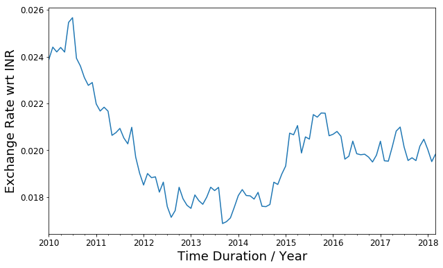

```python
plot1 = df1['AUD'].plot(figsize=(10,6), fontsize=12)      # PLotting the graph for Australian Dollar wrt INR
plot1.set_xlabel("Time Duration / Year", fontsize=18)     # given labes accordingly
plot1.set_ylabel("Exchange Rate wrt INR", fontsize=18)
```

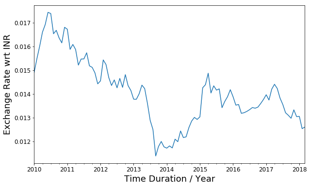

```python
plot2 = df1['EUR'].plot(figsize=(10,6), fontsize=12)        # Plotting the graph for EUR to INR
plot2.set_xlabel("Time Duration / Year", fontsize=18)
plot2.set_ylabel("Exchange Rate wrt INR", fontsize=18)
```

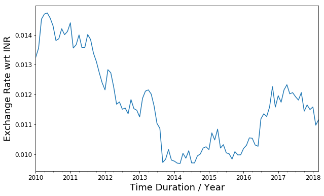

```python
plot3 = df1['GBP'].plot(figsize=(10,6), fontsize=12)        # plot for GBP WRT to INR
plot3.set_xlabel("Time Duration / Year", fontsize=18)
plot3.set_ylabel("Exchange Rate wrt INR", fontsize=18)
```

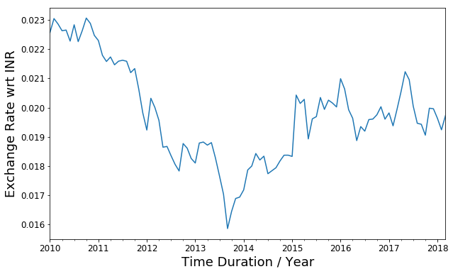

```python
plot4 = df1['CAD'].plot(figsize=(10,6), fontsize=12)     # Plot for Canedian dollar to INR
plot4.set_xlabel("Time Duration / Year", fontsize=18)
plot4.set_ylabel("Exchange Rate wrt INR", fontsize=18)
```